# 1 Setup and reproducibility

# 13a Parameter sweep & winner heatmap (V2)

Building on the sensitivity analysis, this section performs a systematic grid sweep over two key parameters, such as revenue and shortfall penalty, under the V2 objective. For each grid point, the candidate policies are evaluated and the one with the lowest mean cost is identified. The results are visualized as a “winner heatmap” that shows which policy is best in which region of the parameter space. This view makes it easy to explain how economic preferences map to scheduling strategies and where learning-based approaches could add the most value.

```
Sensitivity sweep (lower is better on V2 objective):
 revenue  shortfall_penalty best_policy  best_mean_cost_v2  no_overbook  mild_overbook  aggressive_overbook  bandit_epsgreedy      random
    40.0               10.0 no_overbook        -933.851562  -933.851562      519.23125           637.945312        470.166406  509.967188
    40.0               30.0 no_overbook        -814.164062  -814.164062      539.70000           656.851562        491.650781  480.037500
    40.0               50.0 no_overbook        -694.476562  -694.476562      560.16875           675.757812        598.470312  573.679688
    50.0               10.0 no_overbook       -1474.164062 -1474.164062      -87.95625            30.679687         16.585156 -113.720312
    50.0               30.0 no_overbook       -1354.476562 -1354.476562      -67.48750            49.585937         34.007031  -29.610156
    50.0               50.0 no_overbook       -1234.789062 -1234.789062      -47.01875            68.492187         51.428906  -69.075781
    60.0               10.0 no_overbook       -2014.476562 -2014.476562     -695.14375          -576.585938       -592.946094 -692.959375
    60.0               30.0 no_overbook       -1894.789062 -1894.789062     -674.67500          -557.679688       -575.524219 -677.639844
    60.0               50.0 no_overbook       -1775.101562 -1775.101562     -654.20625          -538.773438       -558.102344 -681.508594
```

```
Saved: report_artifacts/winner_heatmap_v2_20251124_211025.png
```

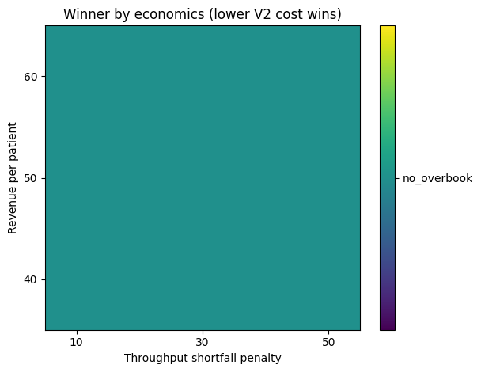

```python
def run_episode_v2(env: ClinicEnvV2, policy_fn):
    obs, info = env.reset()
    total_reward = 0.0
    while True:
        a = policy_fn(obs, env)
        obs, r, terminated, truncated, info = env.step(a)
        total_reward += float(r)
        if terminated or truncated:
            break
    rec = dict(
        reward=total_reward,
        cost_wait=float(info["cost_wait"]),
        cost_overtime=float(info["cost_overtime"]),
        cost_idle=float(info["cost_idle"]),
        cost_no_show=float(info["cost_no_show"]),
        patients_served=int(info["patients_served"]),
        patients_arrived=int(info["patients_arrived"]),
    )
    # add V2 fields (Env V2 supplies them)
    rev = float(info.get("revenue", 0.0))
    pen = float(info.get("shortfall_penalty", 0.0))
    rec["revenue"] = rev
    rec["shortfall_penalty"] = pen
    rec["cost_total"] = rec["cost_wait"] + rec["cost_overtime"] + rec["cost_idle"] + rec["cost_no_show"]
    rec["cost_total_v2"] = rec["cost_total"] - rev + pen
    return rec

def eval_policies_v2_FIXED(env_cfg: ClinicConfig, policies, episodes: int = 256) -> pd.DataFrame:
    rows = []
    for name, pi in policies.items():
        env = ClinicEnvV2(env_cfg)
        for _ in range(episodes):
            rec = run_episode_v2(env, pi)
            rec["policy"] = name
            rows.append(rec)
    return pd.DataFrame(rows)

# grids
rev_grid = [40.0, 50.0, 60.0]
pen_grid = [10.0, 30.0, 50.0]

rows = []
for rev in rev_grid:
    for pen in pen_grid:
        cfg2 = copy.deepcopy(cfg)
        setattr(cfg2, "revenue_per_patient", float(rev))
        setattr(cfg2, "throughput_shortfall_penalty", float(pen))

        # heuristics with correct V2 metric
        df_h = eval_policies_v2_FIXED(cfg2, POLICIES, episodes=128)

        # bandit
        try:
            df_b, _, _ = train_and_eval_bandit_v2(cfg2,
                                                  episodes_train=150,
                                                  episodes_eval=128,
                                                  epsilon=0.1)
            df_all = pd.concat([df_h, df_b], ignore_index=True)
        except NameError:
            df_all = df_h

        means = df_all.groupby("policy")["cost_total_v2"].mean().sort_values()
        best_name, best_val = str(means.index[0]), float(means.iloc[0])

        row = {
            "revenue": rev,
            "shortfall_penalty": pen,
            "best_policy": best_name,
            "best_mean_cost_v2": best_val,
        }
        # record key policies for the printed table
        for name in ["no_overbook","mild_overbook","aggressive_overbook","bandit_epsgreedy","random","dqn"]:
            if name in means.index:
                row[name] = float(means[name])
        rows.append(row)

sweep_table = pd.DataFrame(rows).sort_values(["revenue","shortfall_penalty"]).reset_index(drop=True)
print("Sensitivity sweep (lower is better on V2 objective):")
print(sweep_table.to_string(index=False))

# Heatmap of winners
labels = sorted(sweep_table["best_policy"].unique())
label_to_id = {lab:i for i,lab in enumerate(labels)}
winners = sweep_table.pivot(index="revenue", columns="shortfall_penalty", values="best_policy")
Z = winners.replace(label_to_id)

plt.figure(figsize=(6.2, 4.8))
im = plt.imshow(Z.to_numpy(), aspect="auto", origin="lower",
                extent=[min(pen_grid)-5, max(pen_grid)+5, min(rev_grid)-5, max(rev_grid)+5])
plt.yticks(rev_grid); plt.xticks(pen_grid)
plt.xlabel("Throughput shortfall penalty"); plt.ylabel("Revenue per patient")
plt.title("Winner by economics (lower V2 cost wins)")
cbar = plt.colorbar(im, ticks=range(len(labels)))
cbar.ax.set_yticklabels(labels)
plt.tight_layout()
heatmap_path = os.path.join(ART_DIR, f"winner_heatmap_v2_{now_tag()}.png")
plt.savefig(heatmap_path, dpi=130)
print("Saved:", heatmap_path)
```

# 13b Unknown daily no-show slope and Thompson Sampling bandit

```
Unknown-slope summary (lower is better):
                policy  mean_cost_v2  mean_cost_v2_ci_lo  mean_cost_v2_ci_hi  \
4          no_overbook  -1338.709351        -1390.906860        -1279.743286
2            bandit_ts  -1254.126587        -1318.939453        -1188.606079
3        mild_overbook    -21.551041         -109.464119           71.060860
1     bandit_epsgreedy     13.734897          -91.685287          104.786102
5               random     60.570843          -44.739868          163.849426
0  aggressive_overbook     97.523438            1.564119          191.116394

       var5_v2     cvar5_v2
4  -525.955017  -351.440002
2  -232.975159   -63.639996
3  1106.429810  1341.780029
1  1202.359863  1557.150024
5  1461.625000  1663.550049
0  1275.544800  1602.789917
Saved: report_artifacts/ecdf_envv2_unknown_20251124_211028.png
TS arm counts over days: {0: 191, 1: 1, 2: 0}
Saved: report_artifacts/ts_arm_counts_20251124_211028.png
```

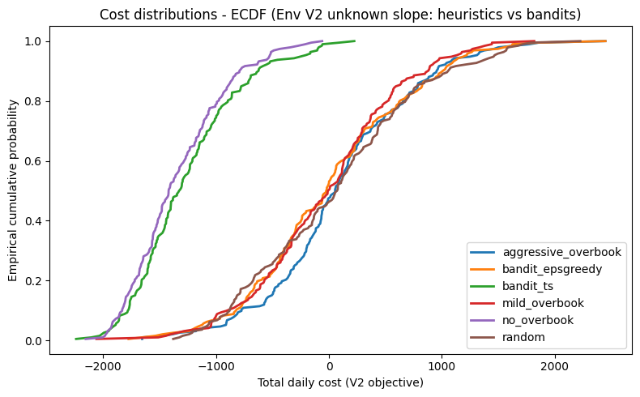

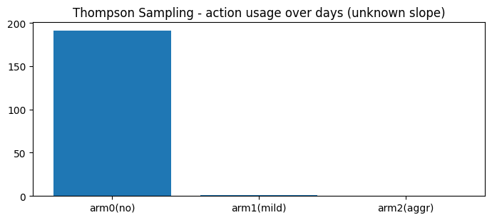

```python
class ClinicEnvV2UnknownSlope(ClinicEnvV2):
    def __init__(self, cfg: ClinicConfig, slope_low=0.02, slope_high=0.14):
        super().__init__(cfg)
        self.slope_low = float(slope_low)
        self.slope_high = float(slope_high)
        self._day_slope = float(cfg.no_show_slope)

    def reset(self, *, seed=None, options=None):
        # sample a new slope each day
        self._day_slope = float(np.random.uniform(self.slope_low, self.slope_high))
        # temporarily override in cfg for this day
        self._orig_slope = self.cfg.no_show_slope
        self.cfg.no_show_slope = self._day_slope
        obs, info = super().reset(seed=seed, options=options)
        return obs, info

    def step(self, action: int):
        return super().step(action)

    def close(self):
        # restore if needed
        self.cfg.no_show_slope = self._orig_slope

# Helpers that operate on V2 objective directly
def run_episode_v2_with_cost(env: ClinicEnvV2, policy_fn):
    obs, info = env.reset()
    while True:
        a = policy_fn(obs, env)
        obs, r, term, trunc, info = env.step(a)
        if term or trunc:
            break
    v2_cost = float(info.get("cost_total_v2",
                             env.cost_wait + env.cost_overtime + env.cost_idle + env.cost_no_show
                             - getattr(env.cfg, "revenue_per_patient", 0.0)*env.patients_served
                             + getattr(env.cfg, "throughput_shortfall_penalty", 0.0)
                               * max(0, int(getattr(env.cfg, "throughput_target", 0)) - env.patients_served)))
    return dict(cost_v2=v2_cost, served=int(info["patients_served"]))

def eval_policies_v2_unknown(env_cfg: ClinicConfig, policies, days=192,
                             slope_low=0.02, slope_high=0.14) -> pd.DataFrame:
    rows = []
    for name, pi in policies.items():
        env = ClinicEnvV2UnknownSlope(env_cfg, slope_low=slope_low, slope_high=slope_high)
        for _ in range(days):
            rec = run_episode_v2_with_cost(env, pi)
            rec["policy"] = name
            rows.append(rec)
    return pd.DataFrame(rows)

# Thompson Sampling bandit (global action per day)
# Arms correspond to "extra booking levels": 0=no_overbook, 1=mild, 2=aggressive
def make_constant_policy(action_level: int):
    def pi(obs, env: ClinicEnv):
        # emulate the corresponding heuristic: spend budget with that level
        if action_level == 0:
            return 0
        if action_level == 1:
            return 1 if env.overbook_remaining >= env.cfg.discrete_overbook_step else 0
        # aggressive
        if env.overbook_remaining >= 2 * env.cfg.discrete_overbook_step and env.action_space.n >= 3:
            return 2
        elif env.overbook_remaining >= env.cfg.discrete_overbook_step:
            return 1
        else:
            return 0
    return pi

class GaussianTS:
    """
    Simple Gaussian Thompson Sampling per-arm with fixed prior scale.
    Reward we feed in is (- cost_v2), so *higher is better*.
    """
    def __init__(self, n_arms=3, prior_mean=0.0, prior_scale=500.0):
        self.n_arms = n_arms
        self.prior_mean = float(prior_mean)
        self.prior_scale = float(prior_scale)
        self.counts = np.zeros(n_arms, dtype=np.int32)
        self.means = np.ones(n_arms, dtype=np.float64)*self.prior_mean

    def select(self):
        # sample one draw per arm: Normal(mean, scale/sqrt(n+1))
        draws = [np.random.normal(self.means[a], self.prior_scale/np.sqrt(self.counts[a]+1.0))
                 for a in range(self.n_arms)]
        return int(np.argmax(draws))

    def update(self, arm, reward):
        # incremental mean update
        n = self.counts[arm]
        m = self.means[arm]
        new_m = m + (reward - m) / (n + 1.0)
        self.means[arm] = new_m
        self.counts[arm] = n + 1

def run_ts_bandit_days(env_cfg: ClinicConfig, days=192, slope_low=0.02, slope_high=0.14):
    ts = GaussianTS(n_arms=3, prior_mean=0.0, prior_scale=500.0)
    env = ClinicEnvV2UnknownSlope(env_cfg, slope_low=slope_low, slope_high=slope_high)
    rows = []
    for d in range(days):
        arm = ts.select()
        pi = make_constant_policy(arm)
        rec = run_episode_v2_with_cost(env, pi)
        reward = -rec["cost_v2"]  # maximize negative cost (minimize cost)
        ts.update(arm, reward)
        rec["policy"] = "bandit_ts"
        rec["arm"] = arm
        rec["day"] = d+1
        rows.append(rec)
    return pd.DataFrame(rows)

# Run unknown-slope experiment
days = 192
slope_low, slope_high = 0.02, 0.14   # daily slope drifts in this range

df_heur = eval_policies_v2_unknown(cfg, {
    "no_overbook": policy_no_overbook,
    "mild_overbook": policy_mild_overbook,
    "aggressive_overbook": policy_aggressive_overbook,
    "random": random_policy,
    "bandit_epsgreedy": POLICIES.get("bandit_epsgreedy", random_policy)  # if defined earlier
}, days=days, slope_low=slope_low, slope_high=slope_high)

df_ts = run_ts_bandit_days(cfg, days=days, slope_low=slope_low, slope_high=slope_high)

# Merge and summarize
df_unknown = pd.concat([df_heur, df_ts], ignore_index=True)

def summarize_v2_unknown(df: pd.DataFrame) -> pd.DataFrame:
    out = []
    for name, g in df.groupby("policy"):
        x = g["cost_v2"].to_numpy(np.float32)
        lo, hi = bootstrap_ci(x, np.mean, B=600, alpha=0.05)
        v, c = var_cvar(x, alpha=0.05)
        out.append(dict(policy=name,
                        mean_cost_v2=float(x.mean()),
                        mean_cost_v2_ci_lo=float(lo),
                        mean_cost_v2_ci_hi=float(hi),
                        var5_v2=float(v),
                        cvar5_v2=float(c)))
    return pd.DataFrame(out).sort_values("mean_cost_v2")
print("Unknown-slope summary (lower is better):")
print(summarize_v2_unknown(df_unknown))

# ECDF on unknown-slope env
plt.figure(figsize=(8,5))
for name, g in df_unknown.groupby("policy"):
    y, x = ecdf(g["cost_v2"].to_numpy())
    plt.plot(y, x, label=name, linewidth=2.0)
plt.xlabel("Total daily cost (V2 objective)")
plt.ylabel("Empirical cumulative probability")
plt.title("Cost distributions - ECDF (Env V2 unknown slope: heuristics vs bandits)")
plt.legend()
plt.tight_layout()
p_ecdf = os.path.join(ART_DIR, f"ecdf_envv2_unknown_{now_tag()}.png")
plt.savefig(p_ecdf, dpi=130)
print("Saved:", p_ecdf)

# Thompson Sampling learning trace: arm selection rates
if "arm" in df_ts.columns:
    sel = df_ts.groupby("arm").size().reindex([0,1,2], fill_value=0)
    print("TS arm counts over days:", sel.to_dict())
    plt.figure(figsize=(7,3.2))
    plt.bar(["arm0(no)","arm1(mild)","arm2(aggr)"], sel.values)
    plt.title("Thompson Sampling - action usage over days (unknown slope)")
    plt.tight_layout()
    p_bar = os.path.join(ART_DIR, f"ts_arm_counts_{now_tag()}.png")
    plt.savefig(p_bar, dpi=130)
    print("Saved:", p_bar)
```

# 13c Wider economics sweep (find the decision boundary)

This section extends the earlier parametric sweeps to explore a broader range of economic settings, with the goal of finding approximate “decision boundaries” between conservative and aggressive booking regimes. It evaluates policies across a large grid of revenue and penalty parameters and identifies regions where overbooking is clearly dominated by safer policies. The results are summarized in tables and plots that make it clear which trade-offs are structurally robust and which are sensitive to small changes in assumptions. This wider sweep sets the stage for the later calibration work by showing how fragile naive economic tuning can be.

```
Wider sweep (lower V2 cost is better):
 revenue  shortfall_penalty best_policy  best_mean_cost_v2  no_overbook  mild_overbook  aggressive_overbook  bandit_epsgreedy       random
    40.0               10.0 no_overbook        -992.020313  -992.020313     473.712500           487.315625        451.944141   392.004687
    40.0               30.0 no_overbook        -851.707813  -851.707813     502.931250           515.128125        483.662891   524.010156
    40.0               50.0 no_overbook        -711.395313  -711.395313     532.150000           542.940625        515.381641   461.190625
    40.0               80.0 no_overbook        -500.926562  -500.926562     575.978125           584.659375        562.959766   516.732031
    40.0              120.0 no_overbook        -220.301563  -220.301563     634.415625           640.284375        614.167969   604.524219
    50.0               10.0 no_overbook       -1521.864063 -1521.864063    -125.037500          -111.825000        -89.287109  -106.187500
    50.0               30.0 no_overbook       -1381.551563 -1381.551563     -95.818750           -84.012500        -60.771484  -128.247656
    50.0               50.0 no_overbook       -1241.239063 -1241.239063     -66.600000           -56.200000        -32.255859   -86.051562
    50.0               80.0 no_overbook       -1030.770313 -1030.770313     -22.771875           -14.481250         10.517578   -53.455469
    50.0              120.0 no_overbook        -750.145313  -750.145313      35.665625            41.143750         67.548828    55.973438
    60.0               10.0 no_overbook       -2051.707812 -2051.707812    -723.787500          -710.965625       -762.617578  -740.660938
    60.0               30.0 no_overbook       -1911.395313 -1911.395313    -694.568750          -683.153125       -733.086328  -687.800781
    60.0               50.0 no_overbook       -1771.082813 -1771.082813    -665.350000          -655.340625       -703.555078  -646.683594
    60.0               80.0 no_overbook       -1560.614063 -1560.614063    -621.521875          -613.621875       -659.258203  -644.285156
    60.0              120.0 no_overbook       -1279.989063 -1279.989063    -563.084375          -557.996875       -600.195703  -599.921094
    80.0               10.0 no_overbook       -3111.395312 -3111.395312   -1921.287500         -1909.246875      -1950.032813 -1987.694531
    80.0               30.0 no_overbook       -2971.082812 -2971.082812   -1892.068750         -1881.434375      -1921.204688 -1883.675000
    80.0               50.0 no_overbook       -2830.770312 -2830.770312   -1862.850000         -1853.621875      -1892.376563 -1882.771094
    80.0               80.0 no_overbook       -2620.301562 -2620.301562   -1819.021875         -1811.903125      -1849.134375 -1804.867969
    80.0              120.0 no_overbook       -2339.676562 -2339.676562   -1760.584375         -1756.278125      -1791.478125 -1782.671094
   100.0               10.0 no_overbook       -4171.082812 -4171.082812   -3118.787500         -3107.528125      -3153.314453 -3122.017188
   100.0               30.0 no_overbook       -4030.770312 -4030.770312   -3089.568750         -3079.715625      -3124.564453 -3173.599219
   100.0               50.0 no_overbook       -3890.457812 -3890.457812   -3060.350000         -3051.903125      -3095.814453 -3056.779687
   100.0               80.0 no_overbook       -3679.989062 -3679.989062   -3016.521875         -3010.184375      -3052.689453 -2990.463281
   100.0              120.0 no_overbook       -3399.364062 -3399.364062   -2958.084375         -2954.559375      -3032.202344 -2943.367969
   120.0               10.0 no_overbook       -5230.770312 -5230.770312   -4316.287500         -4305.809375      -4286.279297 -4342.923437
   120.0               30.0 no_overbook       -5090.457812 -5090.457812   -4287.068750         -4277.996875      -4257.763672 -4319.797656
   120.0               50.0 no_overbook       -4950.145312 -4950.145312   -4257.850000         -4250.184375      -4229.248047 -4236.704687
   120.0               80.0 no_overbook       -4739.676562 -4739.676562   -4214.021875         -4208.465625      -4186.474609 -4253.052344
   120.0              120.0 no_overbook       -4459.051562 -4459.051562   -4155.584375         -4152.840625      -4261.954687 -4150.296875
   150.0               10.0 no_overbook       -6820.301562 -6820.301562   -6112.537500         -6103.231250      -6234.845312 -6174.017969
   150.0               30.0 no_overbook       -6679.989062 -6679.989062   -6083.318750         -6075.418750      -6206.017187 -6132.444531
   150.0               50.0 no_overbook       -6539.676562 -6539.676562   -6054.100000         -6047.606250      -6177.189062 -5987.861719
   150.0               80.0 no_overbook       -6329.207812 -6329.207812   -6010.271875         -6005.887500      -5945.126562 -5942.775781
   150.0              120.0 no_overbook       -6048.582812 -6048.582812   -5951.834375         -5950.262500      -5895.907812 -5930.498438
```

```
Saved: report_artifacts/winner_heatmap_v2_big_20251124_211146.png
```

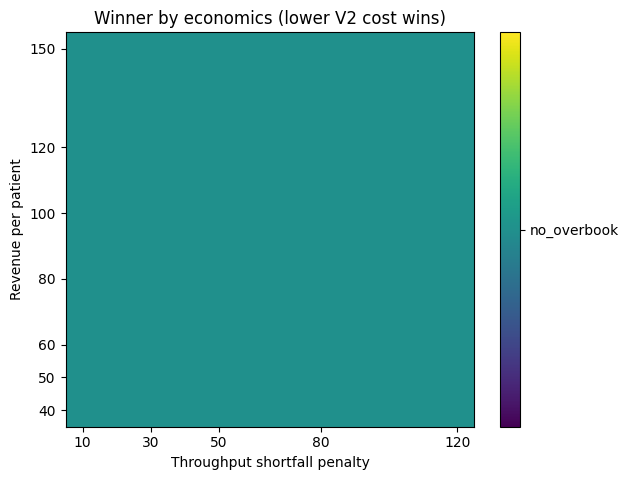

```python
rev_grid = [40.0, 50.0, 60.0, 80.0, 100.0, 120.0, 150.0]
pen_grid = [10.0, 30.0, 50.0, 80.0, 120.0]

rows = []
for rev in rev_grid:
    for pen in pen_grid:
        cfg2 = copy.deepcopy(cfg)
        setattr(cfg2, "revenue_per_patient", float(rev))
        setattr(cfg2, "throughput_shortfall_penalty", float(pen))

        df_h = eval_policies_v2_FIXED(cfg2, POLICIES, episodes=128)

        try:
            df_b, _, _ = train_and_eval_bandit_v2(cfg2,
                                                  episodes_train=200,
                                                  episodes_eval=128,
                                                  epsilon=0.1)
            df_all = pd.concat([df_h, df_b], ignore_index=True)
        except NameError:
            df_all = df_h

        means = df_all.groupby("policy")["cost_total_v2"].mean().sort_values()
        best_name, best_val = str(means.index[0]), float(means.iloc[0])

        row = {"revenue": rev, "shortfall_penalty": pen,
               "best_policy": best_name, "best_mean_cost_v2": best_val}
        for name in ["no_overbook","mild_overbook","aggressive_overbook","bandit_epsgreedy","random","dqn"]:
            if name in means.index:
                row[name] = float(means[name])
        rows.append(row)

sweep_big = pd.DataFrame(rows).sort_values(["revenue","shortfall_penalty"]).reset_index(drop=True)
print("Wider sweep (lower V2 cost is better):")
print(sweep_big.to_string(index=False))

# Winner heatmap
labels = sorted(sweep_big["best_policy"].unique())
label_to_id = {lab:i for i,lab in enumerate(labels)}
winners = sweep_big.pivot(index="revenue", columns="shortfall_penalty", values="best_policy")
Z = winners.replace(label_to_id)

plt.figure(figsize=(6.4, 4.9))
im = plt.imshow(Z.to_numpy(), aspect="auto", origin="lower",
                extent=[min(pen_grid)-5, max(pen_grid)+5, min(rev_grid)-5, max(rev_grid)+5])
plt.xticks(pen_grid); plt.yticks(rev_grid)
plt.xlabel("Throughput shortfall penalty"); plt.ylabel("Revenue per patient")
plt.title("Winner by economics (lower V2 cost wins)")
cbar = plt.colorbar(im, ticks=range(len(labels)))
cbar.ax.set_yticklabels(labels)
plt.tight_layout()
path = os.path.join(ART_DIR, f"winner_heatmap_v2_big_{now_tag()}.png")
plt.savefig(path, dpi=130); print("Saved:", path)
```